# dist-10-transforming-random-variables

```python
from tabulate import tabulate

statistic = ['mean', 'median', 'mode', 'range', 'iqr']
result = ['$x + k = y$', '$x + k = y$', '$x + k = y$', '$x = y$', '$x = y$']

info = dict(statistic = statistic, result = result)

print(tabulate(info, headers = 'keys', tablefmt = 'pipe'))
```

[output not shown]

## Transforming Distributions

Transformation is the process of adding, subtracting some constant value from the measures of central tendency of a distribution. Below you can see the impact (shifting) of adding a constant:

### Shifting A Distribution

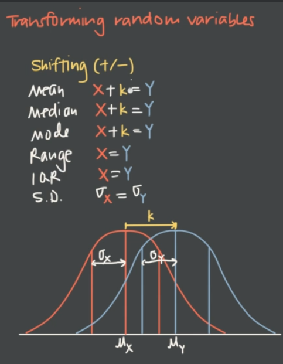

- lets say k = 1 standard deviation
- The red distribution is a standard normal distribution
- A shift to the right denotes a positive shift of 1 std dev as depicted with the blue distribution
- A negative distribution would be a shift to the left 1 std dev
- $\displaystyle \mu_x = 0$
- $\displaystyle \mu_y = 1$
- The range and the IQR stay the same because the distribution is not stretched or shrunk
- The range from the start of the distribution to the end of the distribution is the same so range did not change
- The spread around the median did not change so the IQR is the same
- We see that $\displaystyle \sigma_x = sigma_y$

### Scaling A Distribution

Lets say k = 2  
We multiply the dataset X by k what happens?

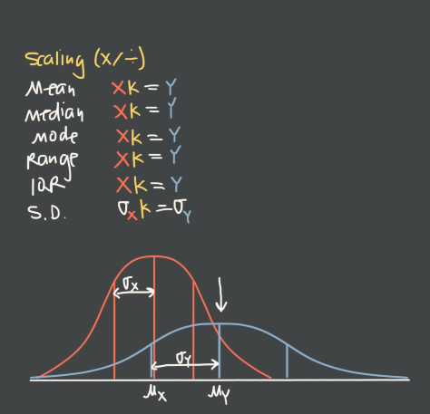

When we multiply X by k, mean, median, mode, range, and IQR are all doubled. This results in the distribution being doubled due to the multiplication of X by k. Keep in mind the area of the distribution cannot change. So the if the length of the distribution doubles, the height of the distribution must be halved. In summary:

- the width of the distribution is 2 X
- mean, median, mode, range, and IQR are all multiplied by 2
- The standard deviation is scaled by k you as well by multiplying by 2